# Análise mortalidade

Caroline de Oliveira Costa

2024-06-23

## 1. Introdução

O objetivo desse relatório é apresentar uma análise exploratória dos dados sobre mortalidade causada pelo uso de psicoativos - CID 10. Os dados foram retirados do banco de dados Datasus, filtrados pelos anos de 2014 até 2017 e por algumas subcategorias da CID 10. Para iniciar, filtraremos o banco de dados para a CID de interesse, nas subdivisões F10 - F19. Utilizaremos para essa análise o banco de dados disponibilizado pelo Rafael Saldanha, no link https://github.com/rfsaldanha/microdatasus. Nesse relatorio será relacionado os dados do estado do Espírito Santo e do Brasil.

### 1.1 Análise descritiva básica

Para uma análise inicial, vamos entender um pouco a situação dos nossos dados. Para estudar sobre a mortalidade causada pelo uso de psicoativos no Espírito Santo, uma informação interessante é que o número de mortes no ES causadas pelo uso de Psicoativos representa 2,6% do total de mortes entre 2014 e 2017 no Brasil, isso equivale a 887 pessoas, enquanto a população do Espírito Santo representa aproximadamente 1,8% da população brasileira (informação retirada do censo de 2010).

Outra informaçõe importante é o número de óbitos por ano e a média de mortes por psicoativos nos anos observados, como podemos visualizar na tabela abaixo.

| Ano | Óbitos.es | Óbitos.br |
| --- | --- | --- |
| 2014 | 235.00 | 8433.0 |
| 2015 | 217.00 | 8467.0 |
| 2016 | 225.00 | 8406.0 |
| 2017 | 210.00 | 8500.0 |
| Média de óbtos/ano | 221.75 | 8451.5 |

### 1.2 Sobre as CIDs

CIDs analizadas:

F10 - Transtornos Mentais e Comportamentais Devidos ao uso de Álcool;

F11 - Transtornos Mentais e Comportamentais Devidos ao uso de Opiáceos;

F12 - Transtornos Mentais e Comportamentais Devidos ao uso de Canabinóides;

F13 - Transtornos Mentais e Comportamentais Devidos ao uso de Sedativos e Hipnóticos;

F14 - Transtornos Mentais e Comportamentais Devidos ao uso da Cocaína;

F15 - Transtornos Mentais e Comportamentais Devidos ao uso de Outros Estimulantes, Inclusive a Cafeína;

F16 - Transtornos Mentais e Comportamentais Devidos ao Uso de Alucinógenos;

F17 - Transtornos Mentais e Comportamentais Devidos ao Uso de Fumo;

F18 - Transtornos Mentais e Comportamentais Devidos ao Uso de Solventes Voláteis;

F19 - Transtornos Mentais e Comportamentais Devidos ao Uso de Múltiplas Drogas e ao uso de outras Substâncias Psicoativas; Cada CID dessa possui mais subcategorias, algumas serão abordadas nessa análise mais para frente.

Fazendo um gráfico analizando a quantidade de óbitos para cada CID, é possível observar que existe uma discrepância entre as diferentes CIDS.

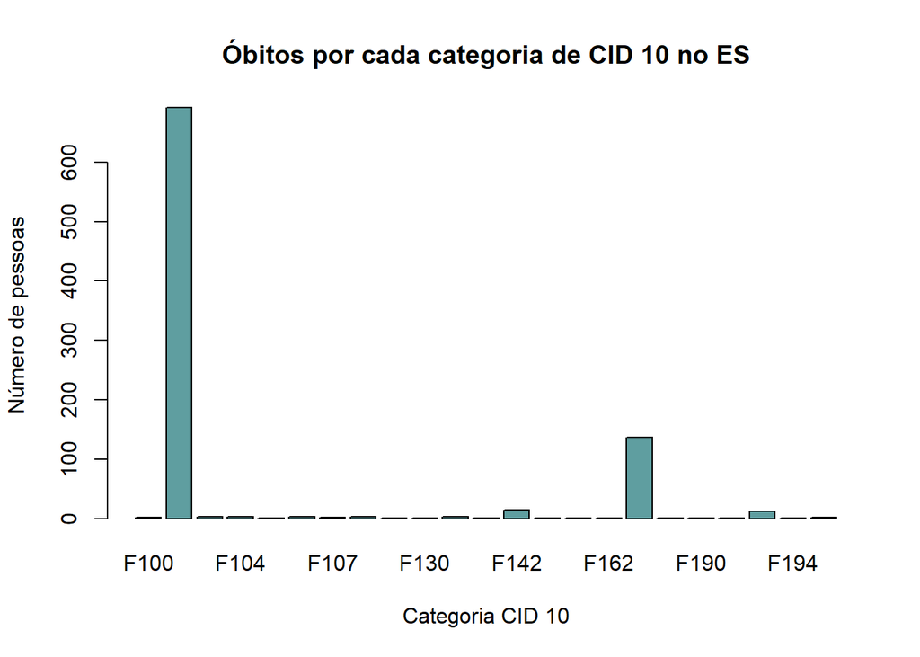

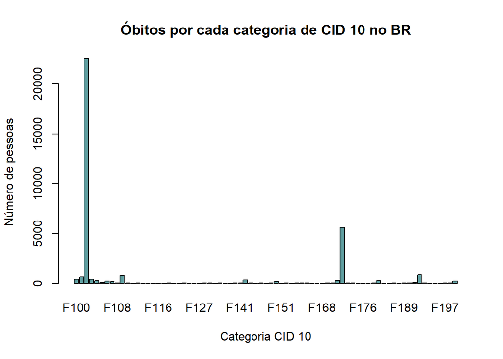

Portanto, serão nosso foco, dentre todas as CIDs, nessa análise.

## 2. Relação Idade e CIDs

### 2.1 Relação mortes por idade no Espírito Santo

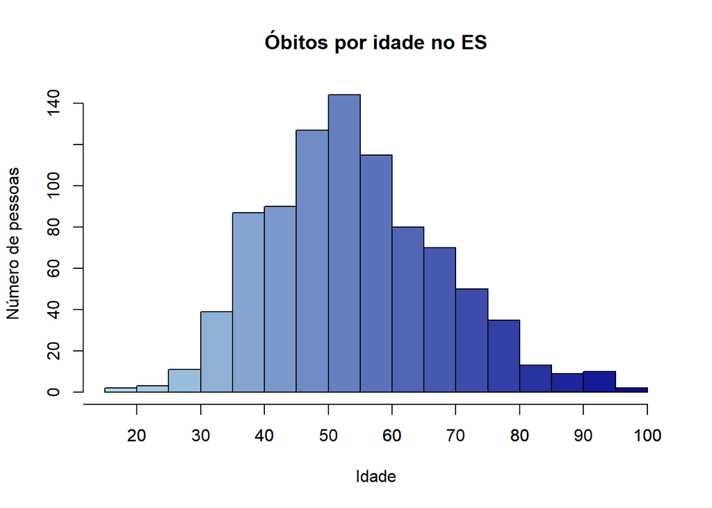

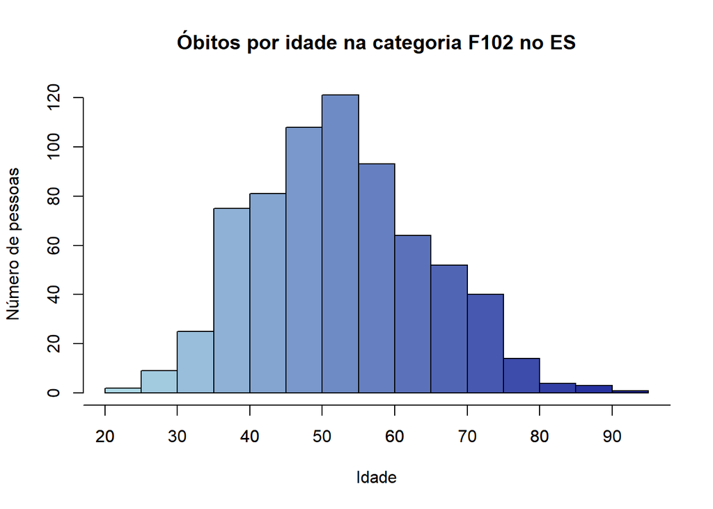

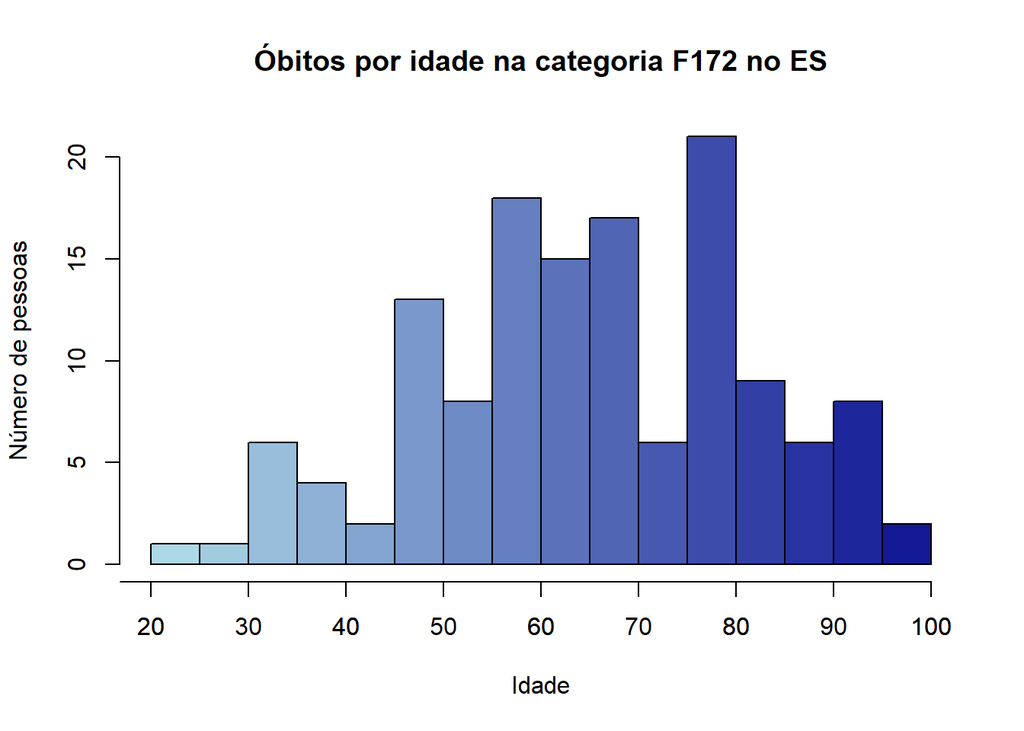

Analisando esses gráficos de óbitos por idade no Espírito Santo, notamos que entre todas as CIDs, temos em sua maioria pessoas entre 50 e 55 anos morrendo devido ao uso de psicoativos. Olhando em específico, no gráfico referente à morte por síndrome de dependência pelo consumo de bebidas alcoólicas(F102), é possível notar a não alteração da faixa de idade com maior número de mortes. Entretanto quando avaliamos as mortes causadas pela abstinência ao fumo(F172), observamos que a maior parte das pessoas tinham entre 75 e 80 anos. É interessante notar também a distribuição dos dados, enquanto nos dois primeiros gráficos o comportamento “padrão” se assemelha a normal, no último notamos que esse “padrão” não existe.

### 2.2 Relação mortes por idade no Brasil

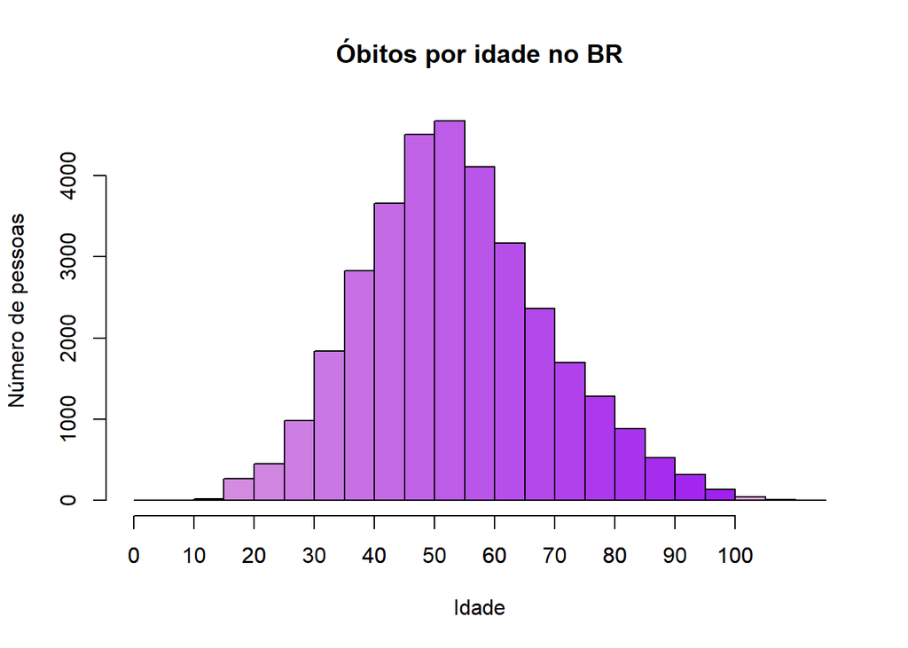

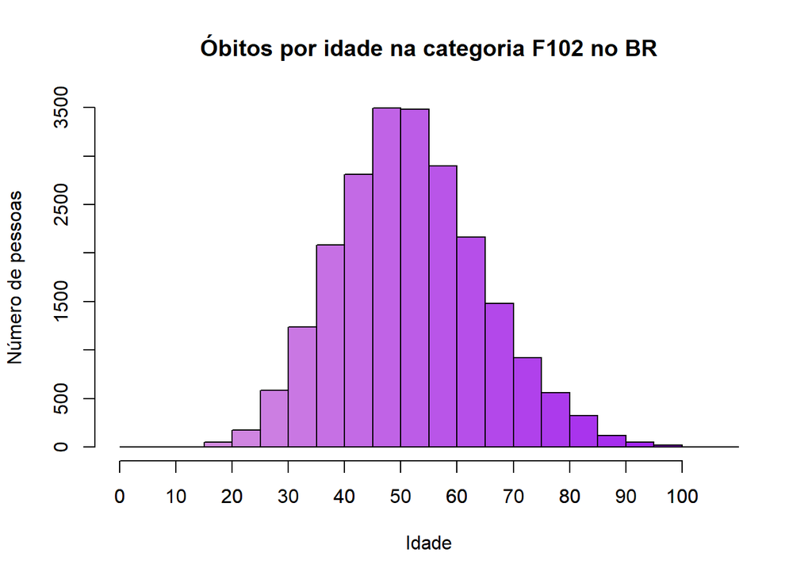

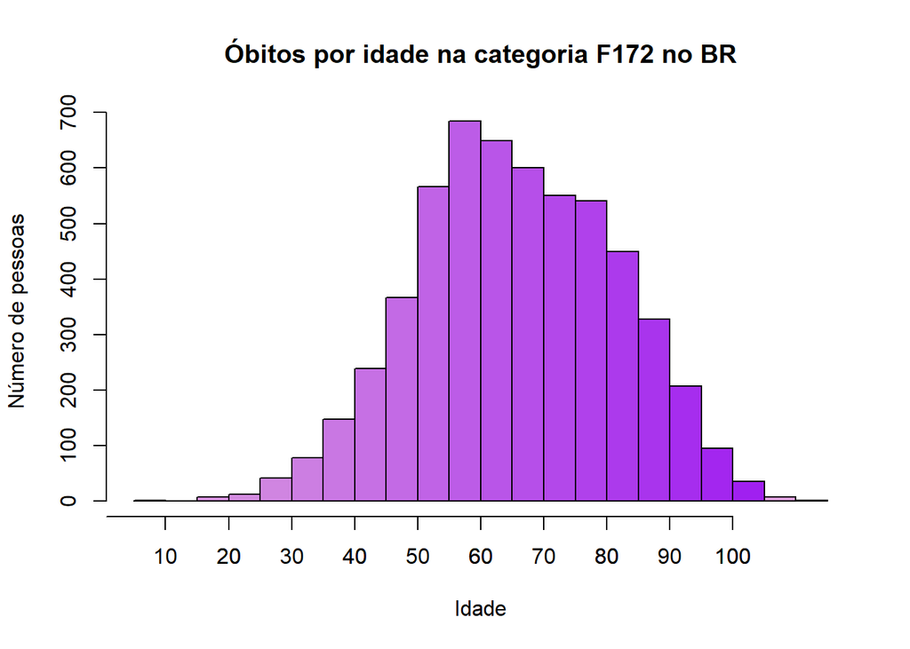

Ao analisar esses gráficos, notamos que a maior diferença entre o Espírito Santo e o Brasil está no gráfico referente ao óbito por abstinência ao fumo(F172), que tem um comportamento parecido com o dos outros dados do Brasil, enquanto se difere no Espírito Santo.

Uma hipótese que pode ser levantada é: - Existe uma relação entre maior idade e morte pela abstinência ao fumo, poderiamos avaliar se isto ocorre devido aos problemas com fumo demorarem para aparecer quando comparado com outras categorias.

## 3. Relação Sexo e mortalidade no Brasil e no Espírito Santo

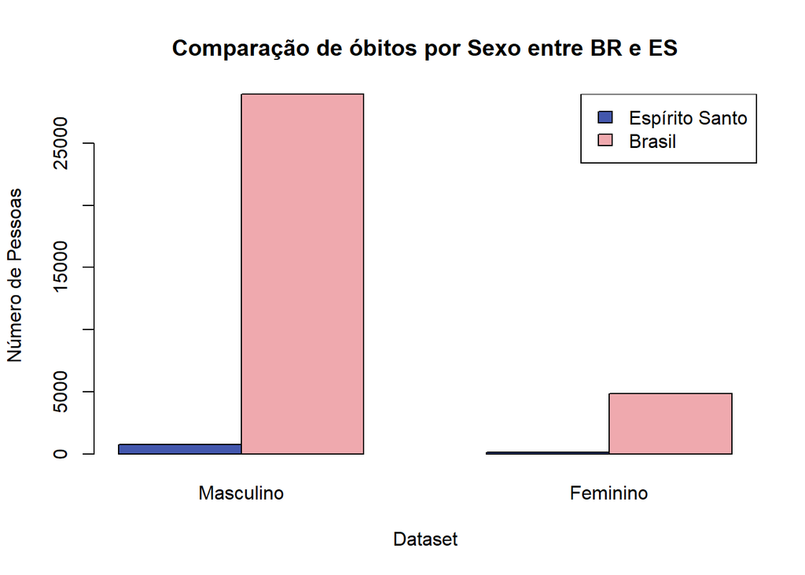

| Local | Masculino.Geral | Feminino.Geral | Masculino.F102 | Feminino.F102 | Masculino.F172 | Feminino.F172 |
| --- | --- | --- | --- | --- | --- | --- |
| ES | 755.000000 | 132.000000 | 608.000000 | 84.000000 | 98.000000 | 39.000000 |
| BR | 28945.000000 | 4849.000000 | 20260.000000 | 2258.000000 | 3913.000000 | 1699.000000 |
| Porcentagem | 2.608395 | 2.722211 | 3.000987 | 3.720106 | 2.504472 | 2.295468 |

Ao olharmos o gráfico, é possível notar que em ambas as situações, pessoas do sexo masculinos morrem mais que pessoas do sexo feminino, e é notável que essa situação ocorre nas diferentes categorias (como é possível observar na tabela acima). Podemos analisar também, posteriormente, a distribuição de sexo por idade para aprofundarmos nossas análises nesse ponto.

## 4. Relação escolaridade e mortalidade no Brasil e Espírito Santo

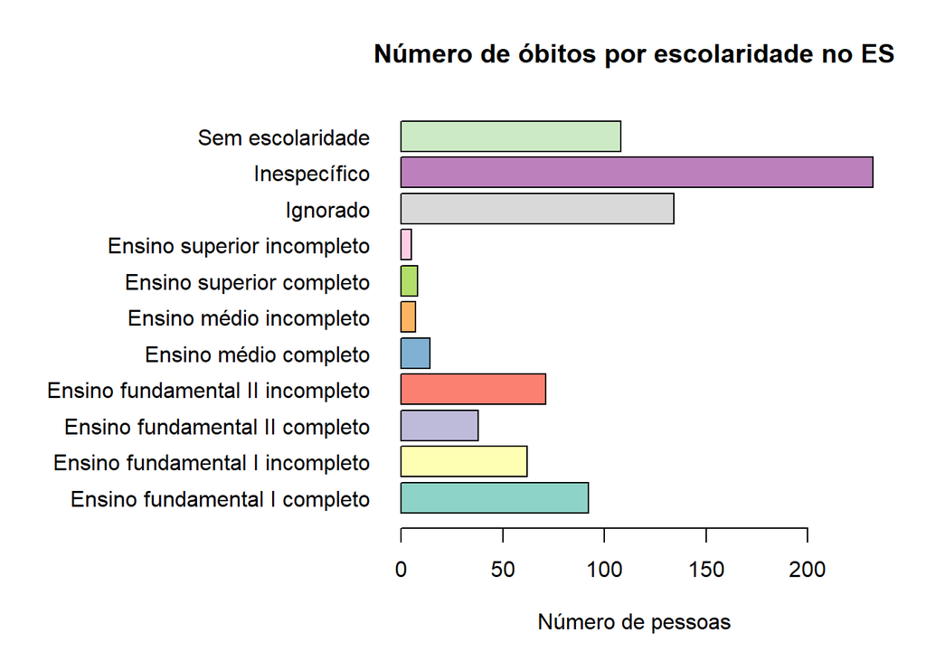

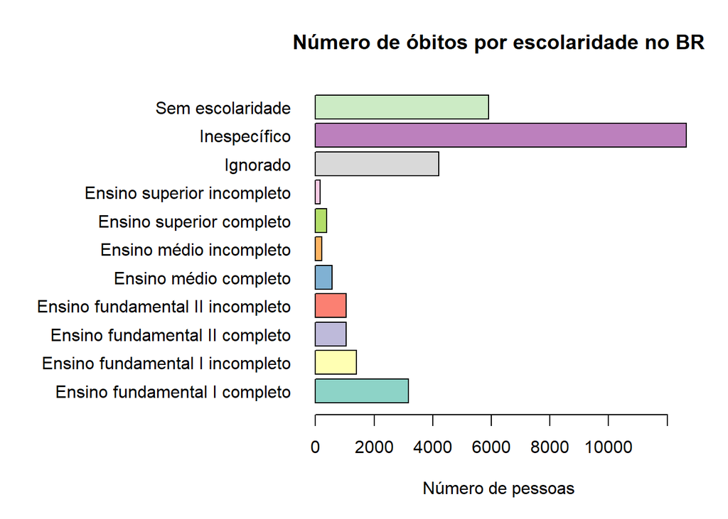

Com esses gráficos é possível levantar a hipótese abaixo sobre seus resultados, como por exemplo:

- Maior parte das pessoas que morreram pelo uso de psicoativos no Espírito Santo e no Brasil não tinham muita instrução, podendo ser mais suscetíveis ao uso de psicoativos. Porém, devido ao alto número de informações inespecíficas, não é possível ser conclusivo em relação à grau de instrução e morte por uso de psicoativos. Como possíveis desmenbramentos, posteriormente podemos relacionar essas informações com outras variáveis, como raça, ocupação, sexo e idade.

## 5. Relação estado civil e mortalidade no Brasil e no Espírito Santo

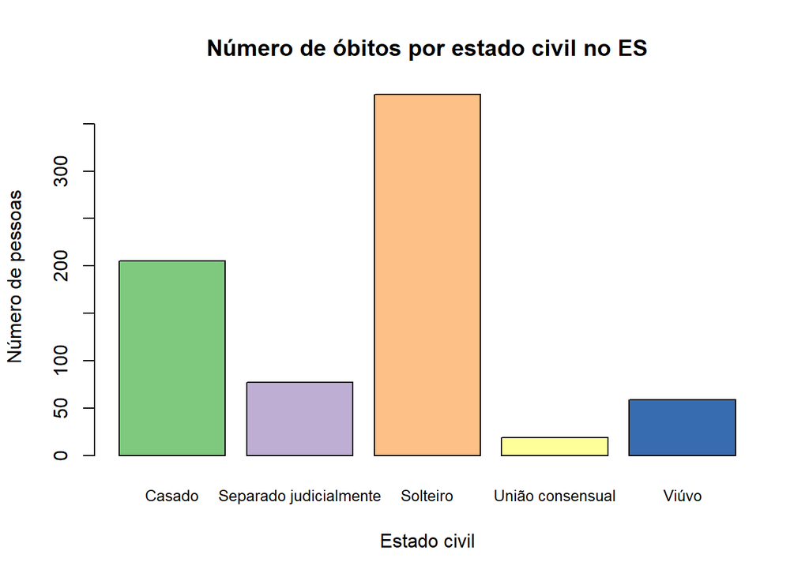

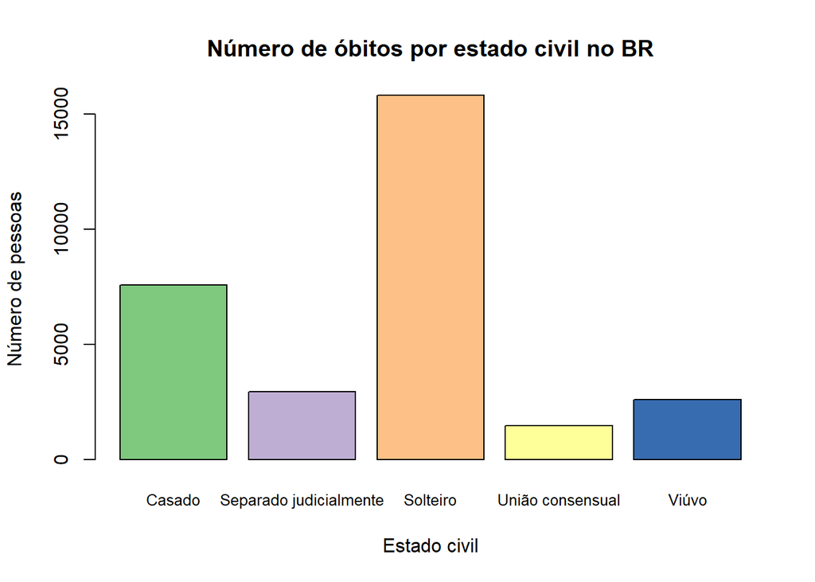

Outra informação que pode ser analisada mais para frente são as mortes por estado civil, nos gráficos acima, é possivel perceber que existe uma tendência maior de pessoas solteiras morrerem mais pelo uso de psicoativos, porém, o dado da forma que está, não é conclusivo.